# Time sync check

## Load libraries

```r
# install.packages(c("bioacoustics", "tuneR", "seewave", "dplyr", "tidyverse", "lubridate", "tools", "ggplot2", "ggpmisc", "plotly", "stringr", "monitoR", "pbapply", "foreach", "doParallel", "R.utils"), type="binary")
library(bioacoustics)
library(tuneR)
library(seewave)
library(dplyr)
library(tidyverse)
library(lubridate)
library(tools)
library(ggplot2)
library(ggpmisc)
library(plotly)
library(stringr)
library(foreach)
library(doParallel)
library(R.utils)
library(readxl)
library(pbapply)
library(monitoR)
ymd_hms = function(dt) {
  lubridate::ymd_hms(dt, tz="Pacific/Auckland")
}
dmy_hms = function(dt) {
  lubridate::dmy_hms(dt, tz="Pacific/Auckland")
}
options(stringsAsFactors = FALSE)
```

## Load RFID log files

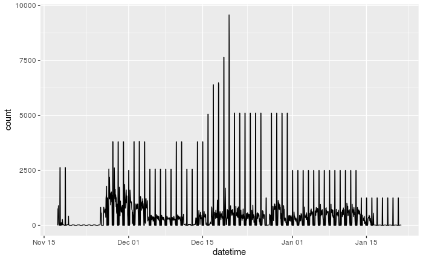

```r
files = list.files("data/2019 RFID", pattern = "*.TXT$", recursive = TRUE, full.names=TRUE)
csvs = lapply(files, function(path) {
  csv = read.csv(path, header=FALSE, col.names = c("year", "month", "day", "hour","minute_sec", "id", "ext", "int", "msg"))
  csv$site = strsplit(strsplit(path, "/")[[1]][4], "_")[[1]][1]
  csv
})
rfid = do.call(rbind, csvs)
rm(csvs)
rfid$datetime = paste0(rfid$year, "-", rfid$month, "-", rfid$day, " ", rfid$hour, ":", rfid$minute_sec)
rfid$datetime = ymd_hms(rfid$datetime)
ggplot(rfid, aes(datetime)) +
  geom_freqpoly(binwidth = 60 * 60)
```

### Reference spectrograms for playback files

```r
html_tag_audio <- function(file, type = c("wav")) {
  type <- match.arg(type)
  htmltools::tags$h3(
    basename(file),
    htmltools::tags$audio(
      controls = "",
      htmltools::tags$source(
        src = file,
        type = glue::glue("audio/{type}", type = type)
      )
    )
  )
}
files = Sys.glob("./clips/PB*.wav")
PB_wavs = lapply(files, function(f) {
  wav = read_audio(f)
  wav_length = round(length(wav) / wav@samp.rate, 2)
  spectro(wav, main=paste0(basename(f), " ", wav_length, "s"), osc=TRUE)
  print(html_tag_audio(f))
  data.frame(filename=basename(f), wav_length)
})
```

### PB0009zp.wav

[interactive chart not shown]

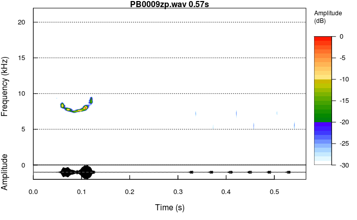

### PB0014zp.wav

[interactive chart not shown]

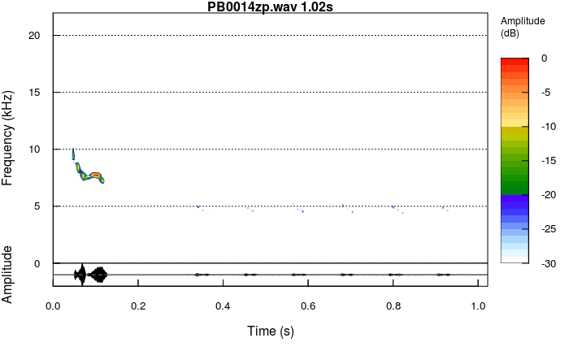

### PB0023.wav

[interactive chart not shown]

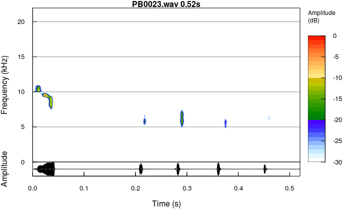

### PB0024.wav

[interactive chart not shown]

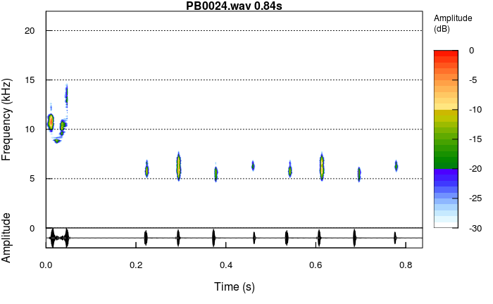

### PBB11up.wav

[interactive chart not shown]

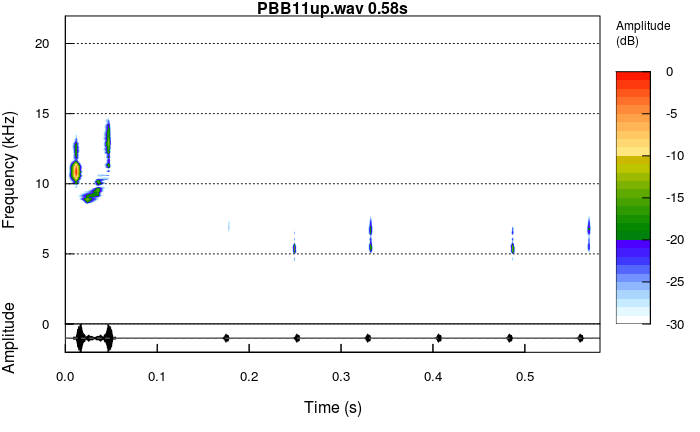

```r
PB_wavs = do.call(rbind, PB_wavs)
```

### Build a reference dataframe showing which wave files correspond to which times

```r
read_BAR_metadata = function(files) {
  df = pblapply(files, function(f) {
    bits = strsplit(basename(f), "_")[[1]]
    start = ymd_hms(paste(bits[2], bits[3]))
    site = strsplit(f, "/")[[1]][4]
    try({
      wav_header = readWave(f, header=TRUE)
      duration = wav_header$samples / wav_header$sample.rate
      end = start + duration
      return(data.frame(filename = f, base_filename = basename(f), site = site, start = start, end = end, samples = wav_header$samples, sr = wav_header$sample.rate, duration=duration, interval = interval(start, end)))
    })
    NULL
  })
  df = do.call(rbind, df)
  df
}
if (file.exists("misc/BAR_timespans.csv")) {
  df = read.csv("misc/BAR_timespans.csv")
  df$start = ymd_hms(df$start)
  df$end = ymd_hms(df$end)
  df$interval = interval(df$start, df$end)
} else {
  files = list.files("data/2019 BAR recordings", pattern = "*.wav$", recursive = TRUE, full.names=TRUE)
  df = read_BAR_metadata(files)
  write.csv(df, "misc/BAR_timespans.csv", row.names = FALSE)
}
df[c("site", "interval")]
```

| site | interval |
| --- | --- |
| NNBB11 | 2019-11-10 16:45:48 NZDT--2019-11-10 16:53:54 NZDT |
| NNBB11 | 2019-11-10 16:54:00 NZDT--2019-11-10 18:53:53 NZDT |
| NNBB11 | 2019-11-10 18:54:40 NZDT--2019-11-10 20:53:53 NZDT |
| NNBB11 | 2019-11-10 20:54:39 NZDT--2019-11-10 22:53:52 NZDT |
| NNBB11 | 2019-11-10 22:54:37 NZDT--2019-11-11 00:53:51 NZDT |
| NNBB11 | 2019-11-10 10:25:38 NZDT--2019-11-10 11:53:58 NZDT |
| NNBB11 | 2019-11-10 13:54:00 NZDT--2019-11-10 15:53:59 NZDT |
| NNBB11 | 2019-11-11 04:53:00 NZDT--2019-11-11 06:52:54 NZDT |
| NNBB11 | 2019-11-11 06:53:41 NZDT--2019-11-11 08:52:50 NZDT |
| NNBB11 | 2019-11-11 08:53:40 NZDT--2019-11-11 10:52:51 NZDT |

[output cut: 990 more lines]

### Select a few playback entries to check

```r
PB_to_check = "PB0023.wav"
site_to_check = "NNK30"
filtered_rfid = filter(rfid, msg == PB_to_check & site == site_to_check)
filtered_df = filter(df, site == site_to_check)
filtered_rfid$corrected_datetime = filtered_rfid$datetime
filtered_rfid$match = lapply(1:nrow(filtered_rfid), function(i) {
  dt = filtered_rfid$corrected_datetime[i]
  site = filtered_rfid$site[i]
  indices = which(dt %within% filtered_df$interval)
  if (length(indices) == 0) indices = NA
  indices
})
print(paste("There are", nrow(filtered_rfid), PB_to_check, "playbacks, of which", sum(!is.na(filtered_rfid$match)), "have recordings"))
```

```
[1] "There are 307 PB0023.wav playbacks, of which 48 have recordings"
```

```r
# A few randomly
datetimes_to_check = sort(sample(filtered_rfid$corrected_datetime[!is.na(filtered_rfid$match)], 5))
# Ones from the 13th
#datetimes_to_check = filtered_rfid$corrected_datetime[!is.na(filtered_rfid$match) & filtered_rfid$datetime > ymd_hms("2019-11-20 00:00:00") & filtered_rfid$datetime < ymd_hms("2019-11-20 23:59:59")]
#datetimes_to_check = filtered_rfid$corrected_datetime[!is.na(filtered_rfid$match) & filtered_rfid$corrected_datetime %within% interval(ymd_hms("2019-12-13 16:45:00"), ymd_hms("2019-12-13 17:13:00"))]
print(datetimes_to_check)
```

```
[1] "2019-12-13 15:04:16 NZDT" "2019-12-13 15:24:06 NZDT" "2019-12-13 16:38:35 NZDT" "2019-12-14 06:20:17 NZDT"
[5] "2019-12-14 06:39:53 NZDT"
```

```
[1] "data/2019 BAR recordings/NNK Kamahi nests/NNK30/NNK30_20191213_STUDY [-39.1072 176.8183]/NNK30_20191213_144041_SunriseToSunset [-39.1072 176.8183].wav 2019-12-13 15:04:16 1415 1416"
[1] "data/2019 BAR recordings/NNK Kamahi nests/NNK30/NNK30_20191213_STUDY [-39.1072 176.8183]/NNK30_20191213_144041_SunriseToSunset [-39.1072 176.8183].wav 2019-12-13 15:24:06 2605 2606"
```

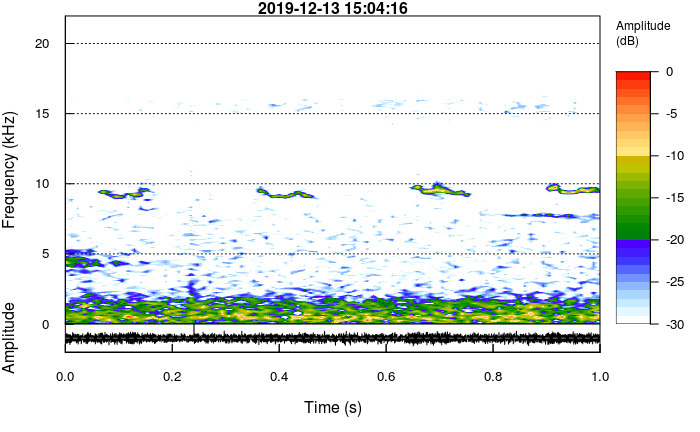

```
[1] "data/2019 BAR recordings/NNK Kamahi nests/NNK30/NNK30_20191213_STUDY [-39.1072 176.8183]/NNK30_20191213_144041_SunriseToSunset [-39.1072 176.8183].wav 2019-12-13 16:38:35 7074 7075"
```

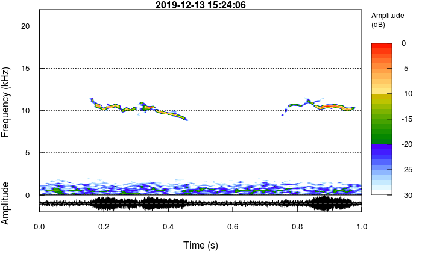

```
[1] "data/2019 BAR recordings/NNK Kamahi nests/NNK30/NNK30_20191214_STUDY [-39.1072 176.8183]/NNK30_20191214_044000_SunriseToSunset [-39.1072 176.8183].wav 2019-12-14 06:20:17 6017 6018"
```

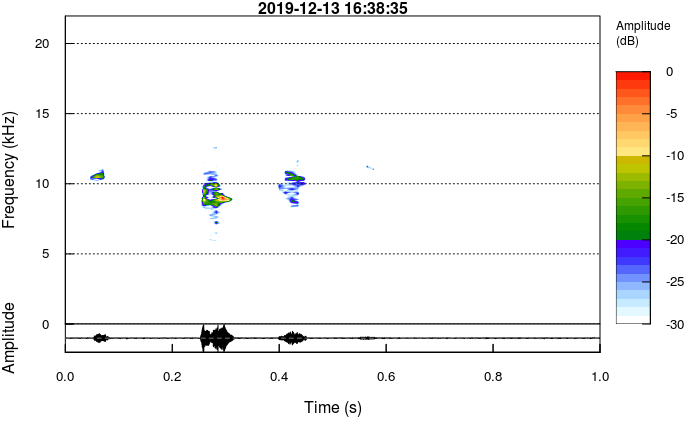

```
[1] "data/2019 BAR recordings/NNK Kamahi nests/NNK30/NNK30_20191214_STUDY [-39.1072 176.8183]/NNK30_20191214_044000_SunriseToSunset [-39.1072 176.8183].wav 2019-12-14 06:39:53 7193 7194"
```

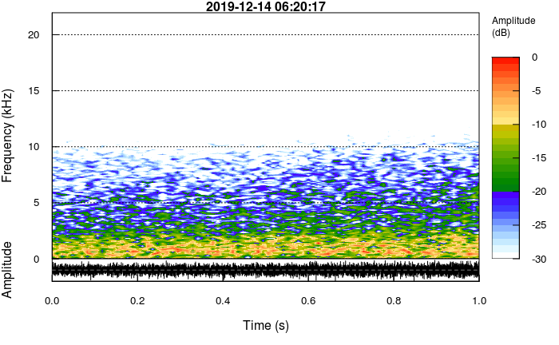

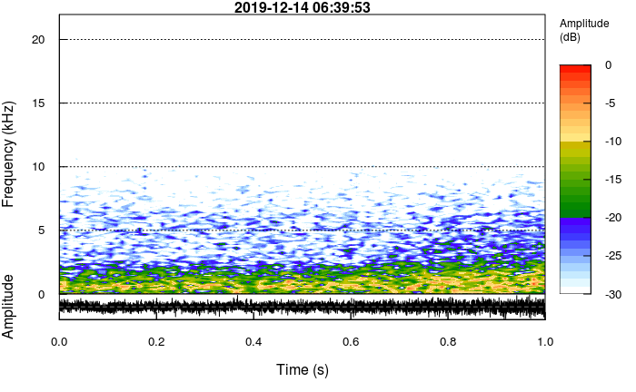

```r
#dt = ymd_hms("2019-12-13 16:45:04")
setWavPlayer("play") # OS dependent
checked_clips = lapply(datetimes_to_check, function(dt) {
  match = filtered_rfid$match[filtered_rfid$corrected_datetime == dt][[1]]
  f = filtered_df$filename[match]
  clip_start = time_length(dt - filtered_df$start[match], unit = "seconds")
  clip_end = clip_start + 1
  print(paste(f, dt, clip_start, clip_end))
  wav = read_audio(f, from = clip_start, to = clip_end)
  spectro(wav, main=dt, osc=TRUE)
  #play(wav)
  wav
})
```

## Write out a csv of approx positions of PB events per wave file

```r
if (file.exists("misc/approx_offsets.csv")) {
  approx_offsets_guide = read.csv("misc/approx_offsets.csv")
} else {
  filtered_rfid = rfid[str_extract(rfid$msg, "^.{2}") == "PB",]
  approx_offsets = lapply(1:nrow(df), function(i) {
    matched_events = filtered_rfid[filtered_rfid$site == df$site[i] & filtered_rfid$datetime %within% df$interval[i],]
    if (nrow(matched_events) == 0) {
      return(NULL)
    }
    if (nrow(matched_events) > 10) {
      matched_events = sample_n(matched_events, 10)
    }
    offsets = time_length(matched_events$datetime - df$start[i])
    data.frame(filename = df$filename[i], offset = offsets, site = matched_events$site, pb = matched_events$msg, datetime = matched_events$datetime)
  })
  approx_offsets_guide = do.call(rbind, approx_offsets)
  write.csv(approx_offsets, "misc/approx_offsets.csv", row.names = FALSE)
}
```

## Compare annotations with nearest RFID log

```r
annotations = lapply(list.files("misc", "*.txt", full.names=TRUE), function(f) {
  if (str_detect(f, "ZOOM")) {
    return(NULL)
  } else if (str_detect(f, "selections")) {
    x = read.table(f, sep="\t", header=TRUE)
    x$datetime = ymd_hms(paste(x$Begin.Date, x$Begin.Clock.Time))
    x = x[c("Begin.Time..s.", "End.Time..s.", "Individual.ID", "Nest.ID", "datetime")]
  } else {
    x = read.table(f, col.names = c("Begin.Time..s.", "End.Time..s.", "Individual.ID"))[c(TRUE, FALSE),]
    x$Begin.Time..s. = as.numeric(x$Begin.Time..s.)
    x$End.Time..s. = as.numeric(x$Begin.Time..s.)
    x$Nest.ID = strsplit(basename(f), "_")[[1]][1]
    x$datetime = df$start[df$base_filename == str_replace(basename(f), ".txt", ".wav")] + x$Begin.Time..s.
  }
  x$filename = paste0(str_replace(basename(f), ".Band.Limited.Energy.Detector.selections.txt|.txt", ""), ".wav")
  x
})
annotations = do.call(rbind, annotations)
annotations$offset = rep(NA, nrow(annotations))
annotations$Individual.ID[annotations$Individual.ID == "PB0009" | annotations$Individual.ID == "PB009"] = "PB0009zp"
annotations$Nest.ID[annotations$Nest.ID == "NKN31"] = "NNK31"
for (i in 1:nrow(annotations)) {
  if (substring(annotations$Individual.ID[i], 0, 2) == "PB") {
    filtered_rfid = filter(rfid, annotations$Nest.ID[i] == site & msg == paste0(annotations$Individual.ID[i], ".wav"))
    matched_rec_start = df$start[df$site == annotations$Nest.ID[i] & annotations$datetime[i] %within% df$interval]
    diffs = time_length(filtered_rfid$datetime - annotations$datetime[i])
    min_i = which.min(abs(diffs))
    offset = diffs[min_i]
    if (length(offset) == 1) {
      annotations$offset[i] = offset
    }
  }
}

approx_offsets = read_excel("misc/approx_offsets.xlsx")
```

[output not shown]

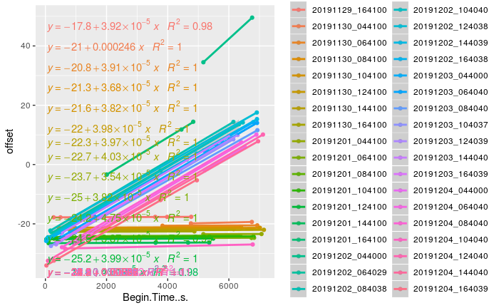

```r
names(approx_offsets) = c("filename", "guide_start", NA, NA, "Begin.Time..s.", "Nest.ID", "Individual.ID", "datetime", NA)
annotations = within(annotations, rm(End.Time..s.))
approx_offsets$offset = approx_offsets$guide_start - approx_offsets$Begin.Time..s.
approx_offsets$filename = basename(approx_offsets$filename)
approx_offsets$Individual.ID = str_replace(approx_offsets$Individual.ID, ".wav", "")
annotations = rbind(annotations, approx_offsets[names(annotations)])

annotations = na.omit(annotations)

filtered_annotations = filter(annotations, offset > -60 & Nest.ID == "NNS1")
ggplot(data = filtered_annotations, aes(x=Begin.Time..s., y=offset, color=substr(basename(filename), start = 6, stop = 20))) +
    geom_point() +
    geom_smooth(method = "lm") +
    stat_poly_eq(formula = y ~ x,
                   aes(label = paste(..eq.label.., ..rr.label.., sep = "~~~")),
                   parse = TRUE) +
    labs(color='file datetime')
```

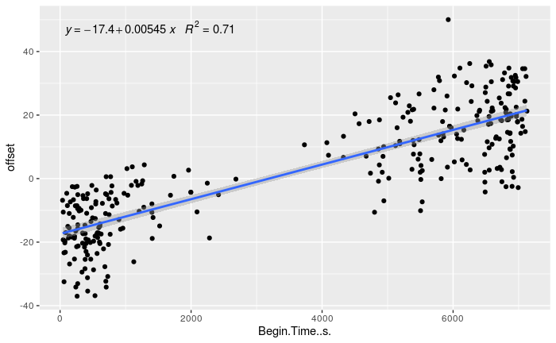

```r
filtered_annotations = filter(annotations, Nest.ID == "NNBB12")
ggplot(data = filtered_annotations, aes(x=Begin.Time..s., y=offset)) +
    geom_point() +
    geom_smooth(method = "lm") +
    stat_poly_eq(formula = y ~ x,
                   aes(label = paste(..eq.label.., ..rr.label.., sep = "~~~")),
                   parse = TRUE)
```

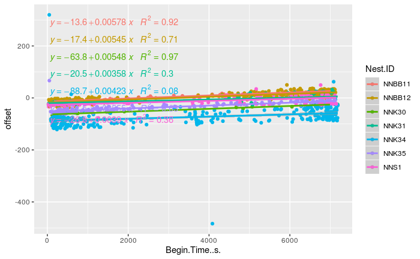

```r
ggplot(data = annotations, aes(x=Begin.Time..s., y=offset, color=Nest.ID)) +
    geom_point() +
    geom_smooth(method = "lm") +
    stat_poly_eq(formula = y ~ x,
                   aes(label = paste(..eq.label.., ..rr.label.., sep = "~~~")),
                   parse = TRUE)
```

Something is wrong with the RFID chip clock - it’s drifting significantly. More data points will help - let’s autodetect PB in the audio files

monitoR seems too unreliable for this task, unfortunately

The reason for the drift is SD card write speed. BAR logfiles indicate the true time packed, so if we read the BAR logfiles we can determine the true sampling rate, and correct it. In some cases, it’ll be just under 44.1KHz.

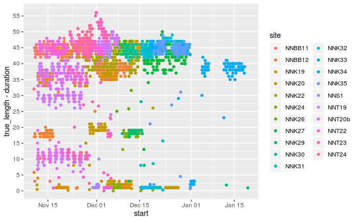

```r
files = list.files("data/2019 BAR recordings", pattern = "logfile.*txt$", recursive = TRUE, full.names=TRUE)
sites = sapply(strsplit(files, "/"), "[[", 4)
df$true_length = rep(NA, nrow(df))
for (site in unique(sites)) {
  files_for_site = files[site == sites]
  lines = unlist(lapply(files_for_site, readLines))
  rec = str_subset(lines, "Recording")
  dt = dmy_hms(str_extract(rec, "^.{19}"))
  rec = rec[order(dt)]
  dt = sort(dt)
  for (i in 1:(length(rec) - 1)) {
    if (str_detect(rec[i], "started") && str_detect(rec[i + 1], "stopped")) {
      filtered_df = df[df$site == site,]
      diffs = time_length(filtered_df$start - dt[i])
      min_i = which.min(abs(diffs))
      min_i = which(df$filename == filtered_df$filename[min_i])
      df$true_length[min_i] = time_length(dt[i+1] - dt[i])
    }
  }
}
ggplot(df[df$site != "KAKA Aviary_20191101_20191113_BAR",], aes(x=start, y=true_length - duration, color = site)) +
  geom_point() +
  scale_y_continuous(breaks = scales::pretty_breaks(n = 10))
```

## Write out waves with corrected sampling rates

The problem with that though, is that sampling rates in wave files are integers - there’s a loss of precision there. It should be possible to multiply a desired second offset by the true sampling rate and slice a wav file that way.

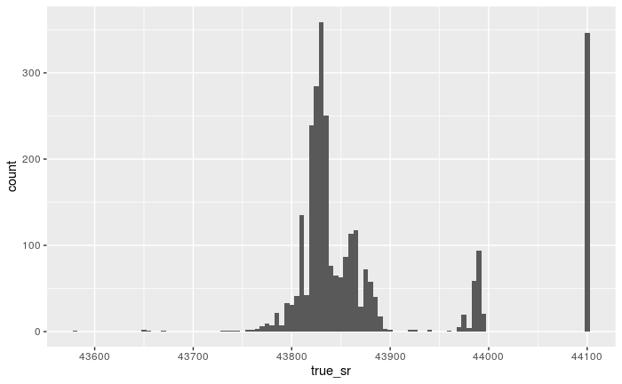

```r
df$true_sr = df$samples / df$true_length
df$true_sr[!is.na(df$true_sr) & df$true_sr > 44000] = 44100
write.csv(df, "misc/BAR_timespans.csv", row.names = FALSE)
ggplot(df[df$duration > 100,], aes(x=true_sr)) +
  geom_histogram(binwidth=5)
```

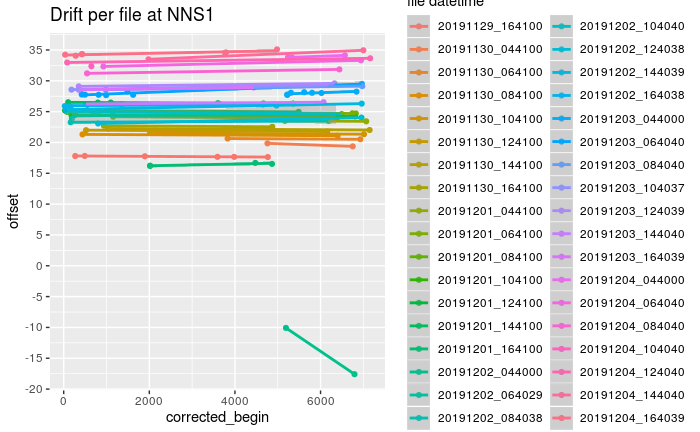

```r
annotations$corrected_begin = sapply(1:nrow(annotations), function(i) {
  true_sr = df$true_sr[str_detect(df$base_filename, fixed(annotations$filename[i]))]
  annotations$Begin.Time..s.[i] * 44100 / true_sr
})
annotations$offset = NA
for (i in 1:nrow(annotations)) {
  if (substring(annotations$Individual.ID[i], 0, 2) == "PB") {
    filtered_rfid = filter(rfid, annotations$Nest.ID[i] == site & msg == paste0(annotations$Individual.ID[i], ".wav"))
    matched_rec_start = df$start[str_detect(df$base_filename, fixed(annotations$filename[i]))]
    rfid_offset = time_length(filtered_rfid$datetime - matched_rec_start)
    diffs = time_length(annotations$corrected_begin[i] - rfid_offset)
    min_i = which.min(abs(diffs))
    offset = diffs[min_i]
    if (length(offset) == 1) {
      annotations$offset[i] = offset
    }
  }
}
filtered_annotations = filter(annotations, Nest.ID == "NNS1" & abs(offset) < 60)
ggplot(data = filtered_annotations, aes(x=corrected_begin, y=offset, color=substr(basename(filename), start = 6, stop = 20))) +
    geom_point() +
    geom_smooth(method = "lm") +
    scale_y_continuous(breaks = scales::pretty_breaks(n = 10)) +
    labs(color='file datetime') +
    stat_poly_eq(formula = y ~ x,
                   aes(label = paste(..eq.label.., ..rr.label.., sep = "~~~")),
                   parse = TRUE) +
    ggtitle("Drift per file at NNS1")
```

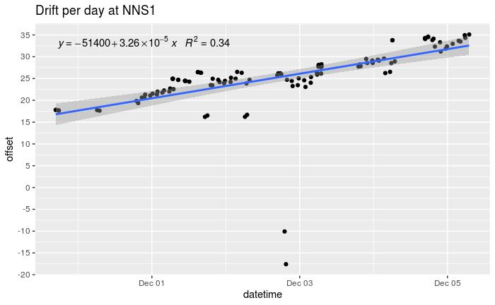

```r
ggplot(data = filtered_annotations, aes(x=datetime, y=offset)) +
    geom_point() +
    geom_smooth(method = "lm") +
    scale_y_continuous(breaks = scales::pretty_breaks(n = 10)) +
    labs(color='file datetime') +
    stat_poly_eq(formula = y ~ x,
                   aes(label = paste(..eq.label.., ..rr.label.., sep = "~~~")),
                   parse = TRUE) +
    ggtitle("Drift per day at NNS1")
```

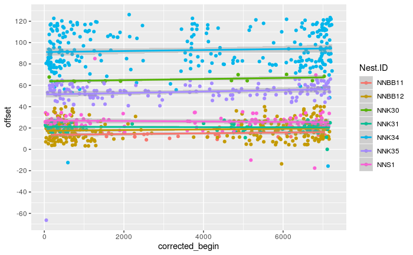

```r
ggplot(data = annotations, aes(x=corrected_begin, y=offset, color=Nest.ID)) +
    geom_point() +
    geom_smooth(method = "lm") +
    scale_y_continuous(breaks = scales::pretty_breaks(n = 10))
```

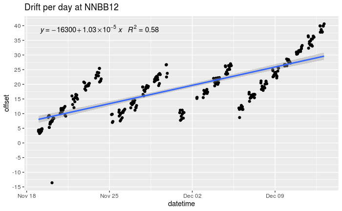

```r
filtered_annotations = filter(annotations, Nest.ID == "NNBB12")
ggplot(data = filtered_annotations, aes(x=datetime, y=offset)) +
    geom_point() +
    geom_smooth(method = "lm") +
    scale_y_continuous(breaks = scales::pretty_breaks(n = 10)) +
    labs(color='file datetime') +
    stat_poly_eq(formula = y ~ x,
                   aes(label = paste(..eq.label.., ..rr.label.., sep = "~~~")),
                   parse = TRUE) +
    ggtitle("Drift per day at NNBB12")
```

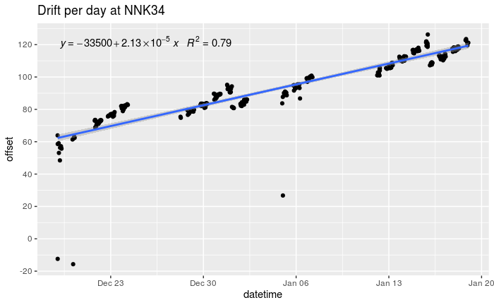

```r
filtered_annotations = filter(annotations, Nest.ID == "NNK34")
ggplot(data = filtered_annotations, aes(x=datetime, y=offset)) +
    geom_point() +
    geom_smooth(method = "lm") +
    scale_y_continuous(breaks = scales::pretty_breaks(n = 10)) +
    labs(color='file datetime') +
    stat_poly_eq(formula = y ~ x,
                   aes(label = paste(..eq.label.., ..rr.label.., sep = "~~~")),
                   parse = TRUE) +
    ggtitle("Drift per day at NNK34")
```